# Month 5 Week 2 Assignment 1

## Task 1

This is an R Markdown document describing the steps taken to complete the assignment from month 5, week 2 of the John Hopkins data science course.

The first step was to load the dataset form the file “activity” which was provided and clean it. The suitable libraries also need to be installed.

```r
library(dplyr)
```

```r
library(ggplot2)
fpath <- "C:/Users/sures/Documents/R/Coursera/Reproducible Research Month 5/Week 2/week-2-month-5"
setwd(fpath)
df <- na.omit(read.csv("activity.csv"))
```

## Task 2

In order to complete the second task of making a histogram of the number of steps taken per day, the tapply function can be used to sort through the dataset. The correct data is then collected and stored in a new dataframe and a binwidth of 500 can be selected to give a clearer picture of the distribution of the data. By using the summary function, both the mean and the median of the data can be found quickly.

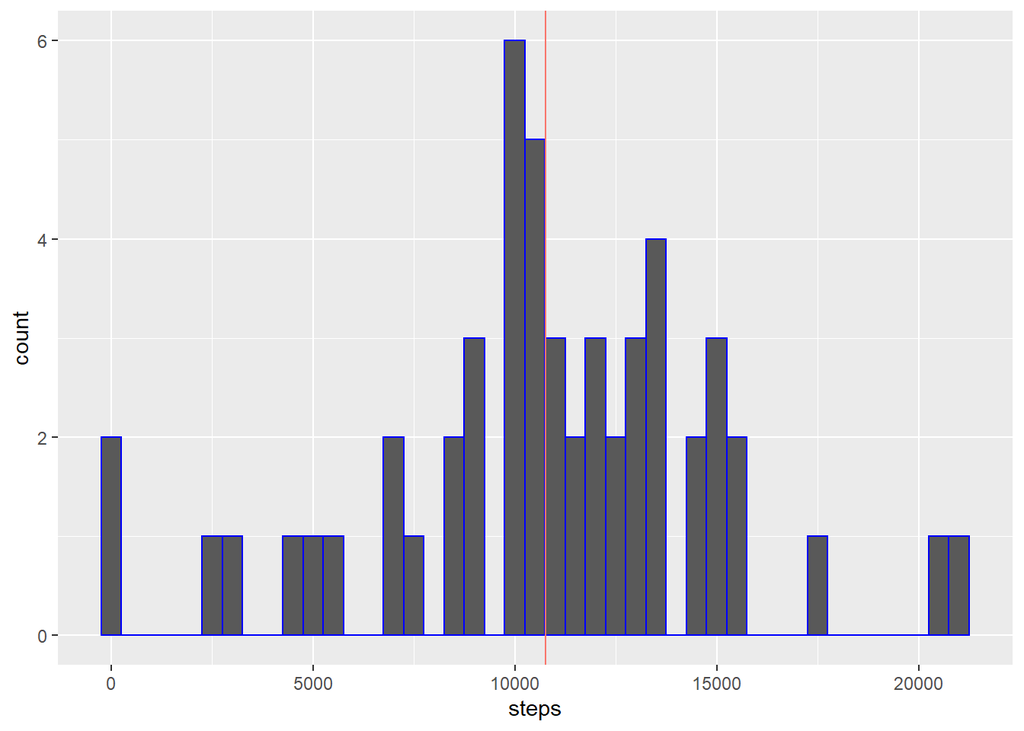

```r
days <- levels(factor(df$date))
df$date <- as.Date(df$date, "%Y-%m-%d")

data <- as.data.frame(with(df, tapply(steps, date, sum)))
data <- cbind(days, data)
colnames(data) <- c("date", "steps")
x <- ggplot(data, aes(x = steps)) +
  geom_histogram(col = "blue", binwidth = 500) +
  geom_vline(aes(xintercept = mean(steps), col = "red", linetype = "dashed")) +
  theme(legend.position = "none")
print(x)
```

```r
print(summary(data))
```

```
##      date               steps
##  Length:53          Min.   :   41
##  Class :character   1st Qu.: 8841
##  Mode  :character   Median :10765
##                     Mean   :10766
##                     3rd Qu.:13294
##                     Max.   :21194
```

## Task 3

With the dataset which has already been imported, tapply can be modified to calculate mean steps per interval for each date. We can then plot the output of tapply with interval to get a time series plot. The two numbers printed below are the highest mean number of steps in a five minute interval and average number of steps over all intervals.

```r
interval <- as.numeric(levels(factor(df$interval)))

data <- as.data.frame(with(df, tapply(steps, interval, mean)))
data <- cbind(interval, data)

colnames(data) <- c("interval", "steps")
max_step <- max(data$steps)
mean_step <- mean(data$steps)


x <- ggplot(data, aes(x = interval, y = steps, group = 1, alpha = 0.5)) +
  geom_point() + geom_hline(yintercept = max_step, linetype = "dashed", color = "blue") +
  geom_hline(yintercept = mean_step, linetype = "dashed", color = "red")
  theme(legend.position = "none")
```

```
## List of 1
##  $ legend.position: chr "none"
##  - attr(*, "class")= chr [1:2] "theme" "gg"
##  - attr(*, "complete")= logi FALSE
##  - attr(*, "validate")= logi TRUE
```

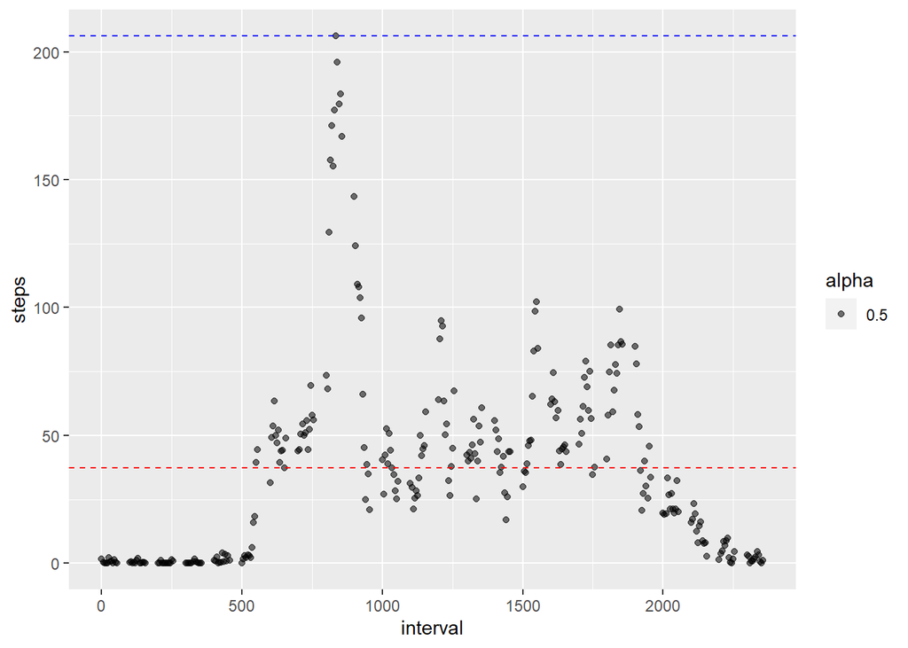

```r
print(x)
```

```r
tab <- table(max_step, mean_step)
print(tab)
```

```
##                   mean_step
## max_step           37.3825995807128
##   206.169811320755                1
```

## Task 4

```r
df <- read.csv("activity.csv")
num_na <- sum(is.na(df$steps))
x <- df$steps

df$steps[is.na(df$steps)] <- mean(df$steps, na.rm = TRUE)

data <- as.data.frame(with(df, tapply(steps, date, sum)))
days <- as.Date(levels(factor(df$date)))

data <- cbind(days, data)
colnames(data) <- c("date", "steps")
print(summary(data))
```

```
##       date                steps
##  Min.   :2012-10-01   Min.   :   41
##  1st Qu.:2012-10-16   1st Qu.: 9819
##  Median :2012-10-31   Median :10766
##  Mean   :2012-10-31   Mean   :10766
##  3rd Qu.:2012-11-15   3rd Qu.:12811
##  Max.   :2012-11-30   Max.   :21194
```

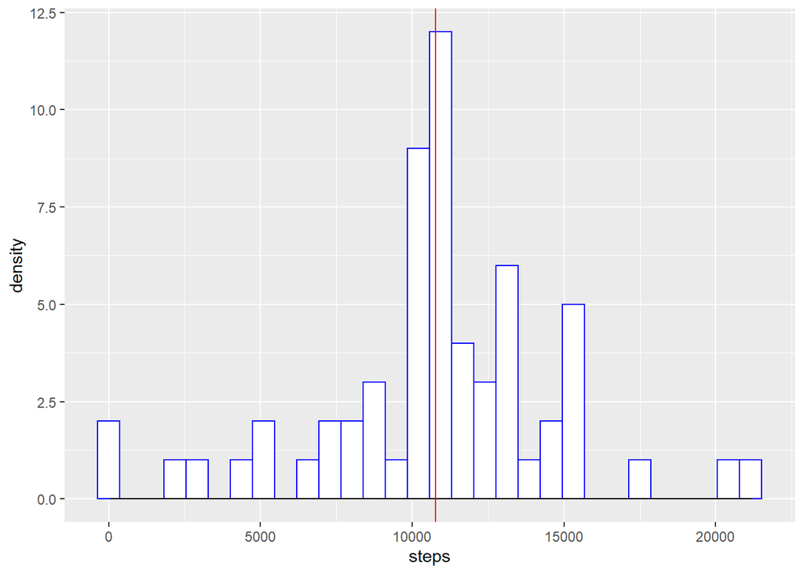

```r
g <- ggplot(data, aes(x = steps)) +
  geom_histogram(col = "Blue", fill = "white", bins = 30) +
  geom_density(alpha = 0.2, fill = "#FF6666")

print(g+geom_vline(aes(xintercept=mean(steps)), col = "red"))
```

```r
print(c(num_na))
```

```
## [1] 2304
```

## Task 5

Using the weekdays() function, we can determine if a date falls on a weekday or weekend. We can the create a new column of data with dplyr from the dataset made in the previous task. Like in task 3, we can use tapply to find the average number of steps per interval and plot using ggplot. We also need the package ggpubr to arrange the plots clearly. We can see that on averege, more steps were taken on weekends compared to weekdays whcih is logical.

```r
library(ggpubr)
```

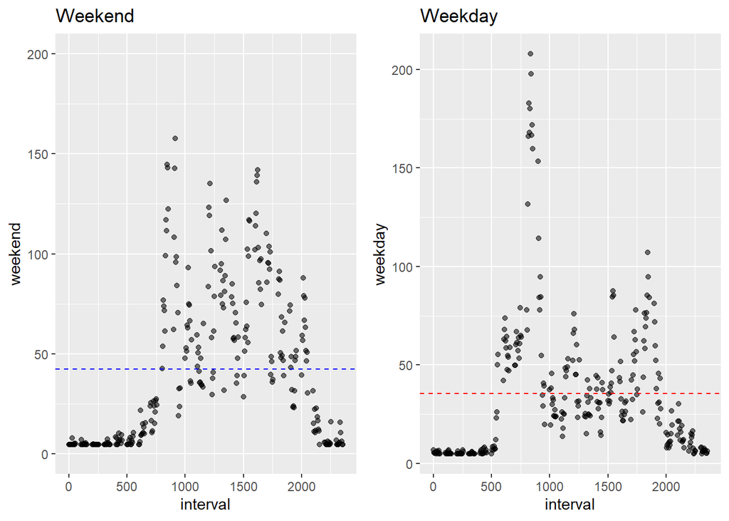

```r
df$interval <- levels(factor(df$interval))
df <- mutate(df, date = as.Date(date))
df <- mutate(df, date_type = weekdays(date))

'%!in%' <- Negate('%in%')
weekend <- subset(df, subset = df$date_type %in% c("Saturday", "Sunday"))
weekend <- as.data.frame(tapply(weekend$steps, weekend$interval, mean))

weekday <- subset(df, subset = df$date_type %!in% c("Saturday", "Sunday"))
weekday <- as.data.frame(tapply(weekday$steps, weekday$interval, mean))

interval <- as.numeric(levels(factor(df$interval)))
data <- cbind(interval, weekday, weekend)
colnames(data) <- c("interval", "weekday", "weekend")
weekend_steps <- mean(data$weekend)
weekday_steps <- mean(data$weekday)


g1 <- ggplot(data, aes(x = interval, y = weekend, alpha = 0.5)) +
  geom_point()+ theme(legend.position = "none") + ggtitle("Weekend") +
  geom_hline(yintercept = weekend_steps, colour = "blue", linetype = "dashed") +
  ylim(0, 200)

g2 <- ggplot(data, aes(x = interval, y = weekday, alpha = 0.5)) +
  geom_point()+ theme(legend.position = "none") + ggtitle("Weekday") +
  geom_hline(yintercept = weekday_steps, colour = "red", linetype = "dashed") +
  scale_x_continuous(breaks = seq(0, 2500, 500))
x <- ggarrange(g1, g2)
print(x)
```